# Modelo de Regressão Linear Múltipla

Heterocedasticidade - Parte 2

Autor

Igor Neves Nunes

```r
# pacotes utilizados
library(tidyverse)  # Metapacote que inclui dplyr, readr, ggplot2, etc.
library(broom)      # converte os resultados de modelos estatísticos em tibbles
library(Ecdat)      # contém conjuntos de dados para econometria
```

# 1 Simulando Modelos Heterocedásticos

## 1.1 Funil

Simulando o exemplo clássico de heterocedasticidade:

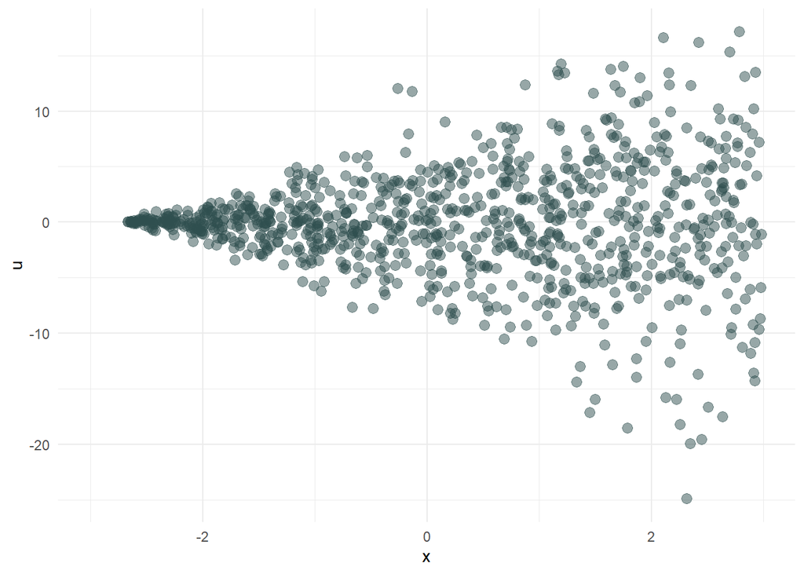

```r
# fixa a semente para reproducibilidade
set.seed(12345)

# simula o funil e salva em uma tibble
dados_funil = tibble(
  x = runif(1000, -3, 3),
  e = rnorm(1000, 0, sd = 4 + 1.5 * x)
)

# grafico de dispersao usando o pacote ggplot2
ggplot(dados_funil, aes(x = x, y = e)) +
geom_point(color = "darkslategrey", size = 2.75, alpha = 0.5) +
labs(x = "x", y = "u") +
theme_minimal()
```

## 1.2 Variâncias Diferentes nos Extremos

Outro exemplo de heterocedasticidade: A variância de $u$ é diferente nos extremos de $x$:

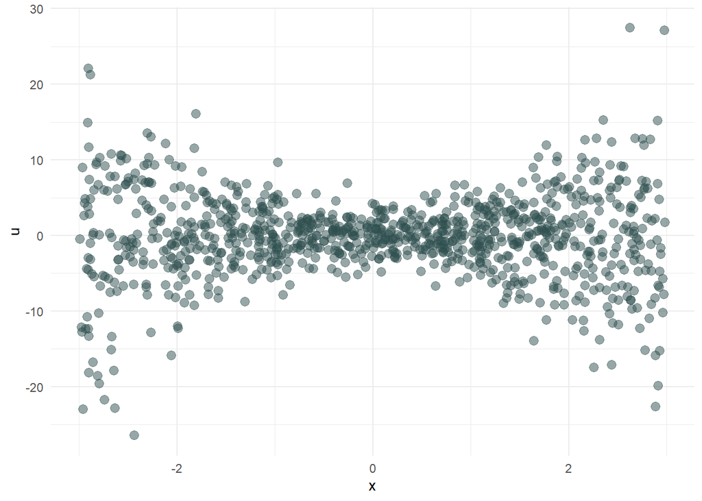

```r
# fixa a semente para reproducibilidade
set.seed(12345)

# simula o funil e salva em uma tibble
dados_extremos = tibble(
  x = runif(1000, -3, 3),
  e = rnorm(1000, 0, sd = 2 + x^2)
)

# grafico de dispersao usando o pacote ggplot2
ggplot(dados_extremos, aes(x = x, y = e)) +
geom_point(color = "darkslategrey", size = 2.75, alpha = 0.5) +
labs(x = "x", y = "u") +
theme_minimal()
```

## 1.3 Grupos com Variâncias Diferentes

Variâncias diferentes de $u$ por grupo:

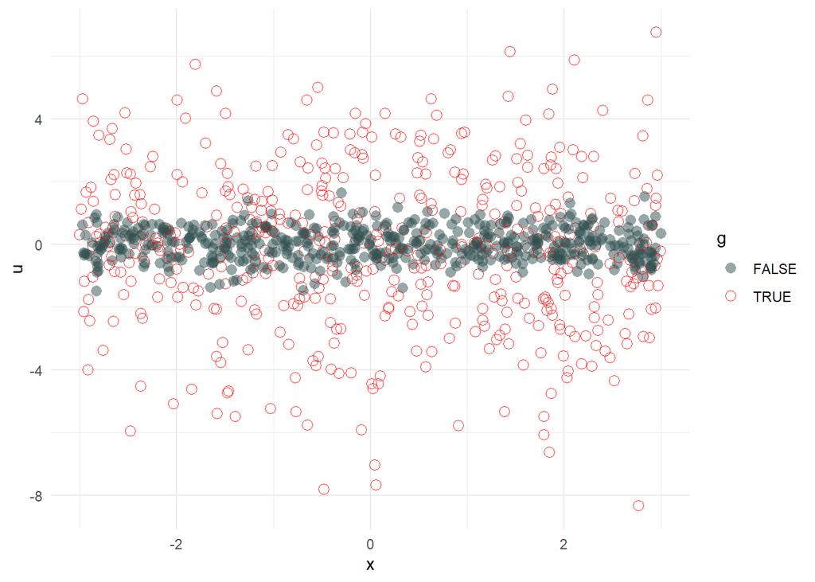

```r
# fixa a semente para reproducibilidade
set.seed(12345)

# simula o funil e salva em uma tibble
dados_grupos = tibble(
  g = sample(c(F,T), 1000, replace = T),
  x = runif(1000, -3, 3),
  e = rnorm(1000, 0, sd = 0.5 + 2 * g)
)

# grafico de dispersao usando o pacote ggplot2
ggplot(dados_grupos, aes(x = x, y = e, color = g, shape = g, alpha = g)) +
geom_point(size = 2.75) +
scale_color_manual(values = c("darkslategrey", "red")) +
scale_shape_manual(values = c(16, 1)) +
scale_alpha_manual(values = c(0.5, 0.8)) +
labs(x = "x", y = "u") +
theme_minimal()
```

# 2 Exemplo: Dados sobre Pontuação em Testes

Voltando ao conjunto de dados sobre pontuações em testes…

```r
# seleciona e renomeie as variáveis desejadas;
# atribui o resultado ao um novo conjunto de dados;
# salva o objeto como tibble
teste_df <- Caschool %>% select(
  test_score = testscr, ratio = str, income = avginc, enrollment = enrltot
) %>% as_tibble()

# visualizando as primeiras 2 linhas
head(teste_df, 2)
```

```
# A tibble: 2 × 4
  test_score ratio income enrollment
       <dbl> <dbl>  <dbl>      <int>
1       691.  17.9  22.7         195
2       661.  21.5   9.82        240
```

Encontramos evidências significativas de heterocedasticidade. Vamos verificar se foi devido à especificação incorreta do nosso modelo:

Modelo 1:

$\text{Score}_i = \beta_0 + \beta_1 \text{Ratio}_i + \beta_2 \text{Income}_i + u_i$

Sintáxe R:

`lm(test_score ~ ratio + income, data = teste_df)`

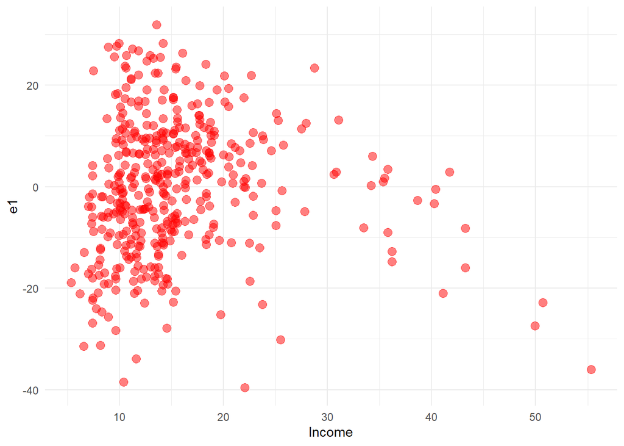

```r
# Estima o modelo 1 e salva os resíduos
teste_df <- teste_df %>%
  mutate(e1 = lm(test_score ~ ratio + income, data = teste_df) %>% residuals())

# grafico dos residuos do modelo 1 contra income
ggplot(data = teste_df, aes(x = income, y = e1)) +
  geom_point(size = 3,
             alpha = 0.5,
             color = "red") +
  labs(x = "Income", y = "e1") +
  theme_minimal()
```

Modelo 2:

$$\log\left(\text{Score}_i\right) = \beta_0 + \beta_1 \text{Ratio}_i + \beta_2 \text{Income}_i + u_i$$

Sintáxe R:

`lm(log(test_score) ~ ratio + income, data = teste_df)`

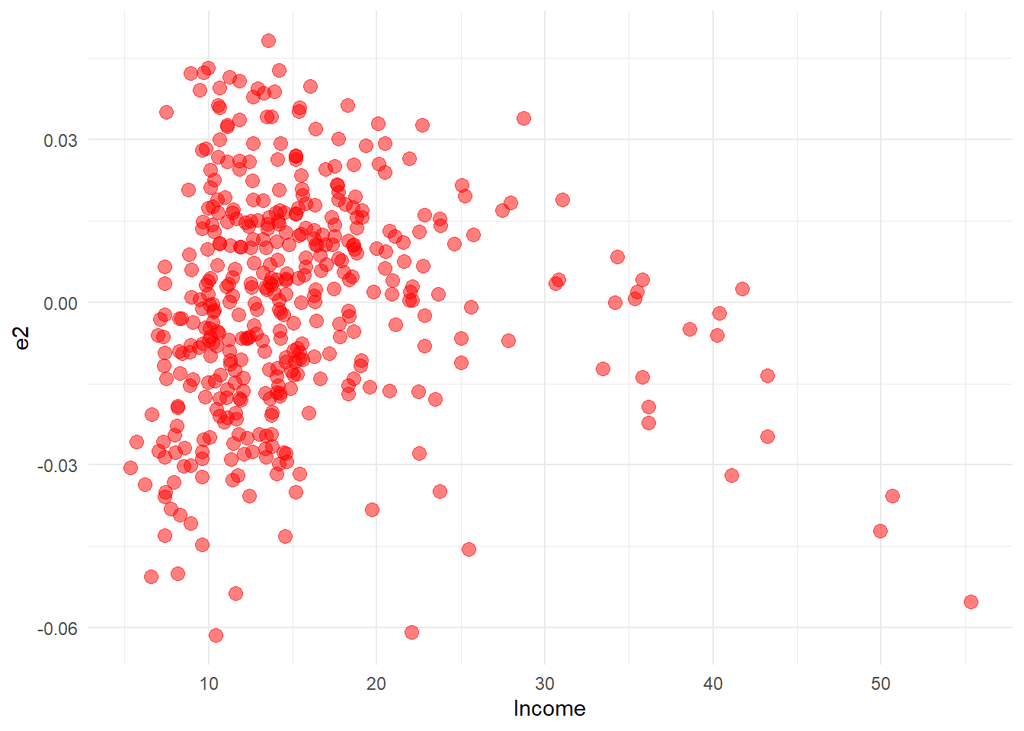

```r
# Estima o modelo 2 e salva os resíduos
teste_df <- teste_df %>%
  mutate(e2 = lm(log(test_score) ~ ratio + income, data = teste_df) %>% residuals())

# grafico dos residuos do modelo 2 contra income
ggplot(data = teste_df, aes(x = income)) +
  geom_point(aes(y = e2),
             size = 3,
             alpha = 0.5,
             color = "red") +
  labs(x = "Income", y = "e2") +
  theme_minimal()
```

Modelo 3:

$$\log\left(\text{Score}_i\right) = \beta_0 + \beta_1 \text{Ratio}_i + \beta_2 \log\left(\text{Income}_i\right) + u_i$$

Sintáxe R:

`lm(log(test_score) ~ ratio + log(income), data = teste_df)`

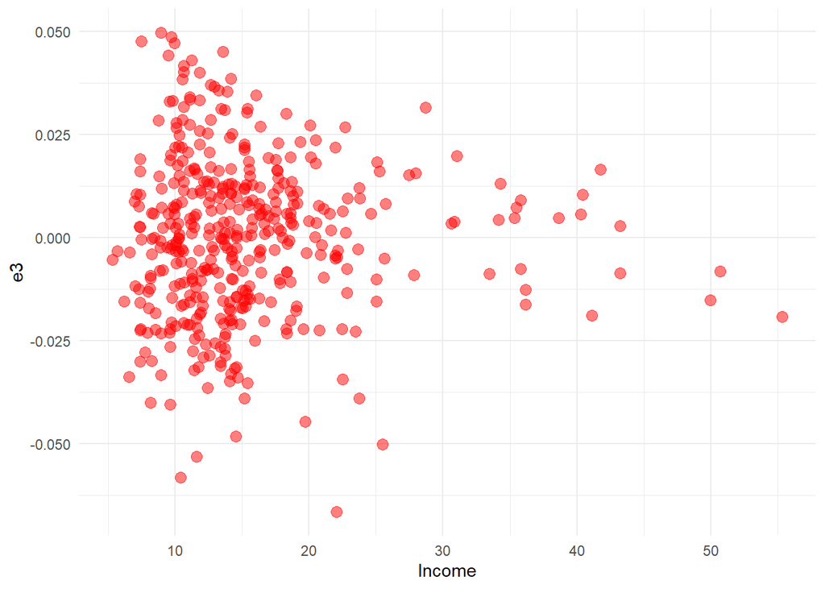

```r
# Estima o modelo 3 e salva os resíduos
teste_df <- teste_df %>%
mutate(e3 = lm(log(test_score) ~ ratio + log(income), data = teste_df) %>% residuals())

# Plot
ggplot(data = teste_df, aes(x = income)) +
  geom_point(aes(y = e3),
             size = 3,
             alpha = 0.5,
             color = "red") +
  labs(x = "Income", y = "e3") +
  theme_minimal()
```

Vamos testar essa nova especificação (Modelo 3) com o teste de White para heterocedasticidade.

```r
reg_white <- lm(e3^2 ~
  ratio * log(income) + I(ratio^2) + I(log(income)^2),
  data = teste_df
)

white_r2_spec <- summary(reg_white)$r.squared

white_stat_spec <- white_r2_spec * 420
white_stat_spec
```

```
[1] 12.16412
```

Neste caso, a regressão para o teste de White é :

$$\begin{align}
e_i^2 = &\alpha_0 + \alpha_1 \text{Ratio}_i + \alpha_2 \log\left(\text{Income}_i\right) + \alpha_3 \text{Ratio}_i^2 + \alpha_4 \left(\log\left(\text{Income}_i\right)\right)^2 \\
&+ \alpha_5 \left(\text{Ratio}_i\times\log\left(\text{Income}_i\right)\right) + v_i
\end{align}$$

que produz $R_e^2\approx0.029$, sendo o valor da estatística de teste: $\widehat{\text{LM}} = n\times R_e^2 \approx 12.2$.

Sob a hipótese nula, a estatística do teste de White ($\text{LM}$) segue uma distribuição $\chi_5^2$ $\implies$ valor-p $\approx$ 0.033. Portanto, Rejeitamos a hipótese nula.

Conclusão: Há evidências estatisticamente significativas de heterocedasticidade no nível de significância de 5%.

Ok, tentamos ajustar nossa especificação, mas ainda há evidências de heterocedasticidade.

**Nota:** Em geral, recorremos a erros padrão robustos à heterocedasticidade.

- Os estimadores de MQO ainda são não viesados para os coeficientes (os $\beta_j$’s).
- Erros padrão robustos à heterocedasticidade são não viesados para os erros padrão dos $\hat{\beta}_j$’s, isto é, $\sqrt{\mathop{\text{Var}} \left( \hat{\beta}_j \right)}$.

Vamos retornar ao nosso modelo

$$\text{Score}_i = \beta_0 + \beta_1 \text{Ratio}_i + \beta_2 \text{Income}_i + u_i$$

Podemos usar o pacote `lfe` de R para calcular erros padrão robustos à heterocedasticidade.

1.Execute a regressão usando a função `felm()` do pacote `lfe` (em vez de `lm()`):

```r
library(lfe)

# estima o modelo de regressao
test_reg <- felm(test_score ~ ratio + income, data = teste_df)
```

*Observe* que `felm()` usa a mesma sintaxe que `lm()` para esta regressão.

2. Estime erros padrão robustos à heterocedasticidade usando o argumento `robust = T` da função `summary()`:

```r
# erros padrão robustos à heterocedasticidade com 'robust = T'
summary(test_reg, robust = T)
```

```
Call:
   felm(formula = test_score ~ ratio + income, data = teste_df)

Residuals:
    Min      1Q  Median      3Q     Max
-39.608  -9.052   0.707   9.259  31.898

Coefficients:
            Estimate Robust s.e t value Pr(>|t|)
(Intercept) 638.7292     7.3012  87.482   <2e-16 ***
ratio        -0.6487     0.3533  -1.836   0.0671 .
income        1.8391     0.1147  16.029   <2e-16 ***
---
Signif. codes:  0 '***' 0.001 '**' 0.01 '*' 0.05 '.' 0.1 ' ' 1

Residual standard error: 13.35 on 417 degrees of freedom
Multiple R-squared(full model): 0.5115   Adjusted R-squared: 0.5091
Multiple R-squared(proj model): 0.5115   Adjusted R-squared: 0.5091
F-statistic(full model, *iid*):218.3 on 2 and 417 DF, p-value: < 2.2e-16
F-statistic(proj model): 132.7 on 2 and 417 DF, p-value: < 2.2e-16
```

## 2.1 Comparação

Estimativas dos Parâmetros e **erros padrão robustos à heterocedasticidade**:

```r
summary(test_reg, robust = T)
```

```
Call:
   felm(formula = test_score ~ ratio + income, data = teste_df)

Residuals:
    Min      1Q  Median      3Q     Max
-39.608  -9.052   0.707   9.259  31.898

Coefficients:
            Estimate Robust s.e t value Pr(>|t|)
(Intercept) 638.7292     7.3012  87.482   <2e-16 ***
ratio        -0.6487     0.3533  -1.836   0.0671 .
income        1.8391     0.1147  16.029   <2e-16 ***
---
Signif. codes:  0 '***' 0.001 '**' 0.01 '*' 0.05 '.' 0.1 ' ' 1

Residual standard error: 13.35 on 417 degrees of freedom
Multiple R-squared(full model): 0.5115   Adjusted R-squared: 0.5091
Multiple R-squared(proj model): 0.5115   Adjusted R-squared: 0.5091
F-statistic(full model, *iid*):218.3 on 2 and 417 DF, p-value: < 2.2e-16
F-statistic(proj model): 132.7 on 2 and 417 DF, p-value: < 2.2e-16
```

Estimativas dos Parâmetros e **erros padrão com MQO** (assume homocedasticidade):

```r
summary(test_reg, robust = F)
```

```
Call:
   felm(formula = test_score ~ ratio + income, data = teste_df)

Residuals:
    Min      1Q  Median      3Q     Max
-39.608  -9.052   0.707   9.259  31.898

Coefficients:
             Estimate Std. Error t value Pr(>|t|)
(Intercept) 638.72915    7.44908  85.746   <2e-16 ***
ratio        -0.64874    0.35440  -1.831   0.0679 .
income        1.83911    0.09279  19.821   <2e-16 ***
---
Signif. codes:  0 '***' 0.001 '**' 0.01 '*' 0.05 '.' 0.1 ' ' 1

Residual standard error: 13.35 on 417 degrees of freedom
Multiple R-squared(full model): 0.5115   Adjusted R-squared: 0.5091
Multiple R-squared(proj model): 0.5115   Adjusted R-squared: 0.5091
F-statistic(full model):218.3 on 2 and 417 DF, p-value: < 2.2e-16
F-statistic(proj model): 218.3 on 2 and 417 DF, p-value: < 2.2e-16
```

# 3 Exemplo: Mínimos Quadrados Ponderados

## 3.1 Implementando WLS Manualmente

Mencionamos que muitas vezes não é possível aplicar o método WLS — pois precisamos saber a forma funcional da heterocedasticidade, ou seja, precisamos saber:

**A**. $\sigma_i^2$

ou

**B**. $h(x_i)$, sendo $\sigma_i^2 = \sigma^2 h(x_i)$

Entretanto, há ocasiões em que podemos saber $h(x_i)$.

Imagine que indivíduos em uma população têm erros homocedásticos.

Entretanto, em vez de observar dados individuais, observamos médias de grupos (por exemplo, médias de escolas, cidades, etc.).

Se esses grupos tiverem tamanhos diferentes, nosso conjunto de dados será heteroscedástico, de forma previsível.

**Lembre-se:** A variância da média da amostra depende do tamanho da amostra,

$$V(\bar{x}) = \dfrac{\sigma_x^2}{n}$$

**Exemplo:** Nossos dados de testes escolares são calculados em média no nível da escola.

*Exemplo:* São tomadas médidas dos testes no nível da escola.

Mesmo que alunos individuais tenham erros homocedásticos, as escolas teriam distúrbios heterocedásticos, *ou seja*,

**Modelo nível-individual:**

$$\text{Score}_i = \beta_0 + \beta_1 \text{Ratio}_i + \beta_2 \text{Income}_i + u_i$$

**Modelo nível-escola:**

$$\overline{\text{Score}}_s = \beta_0 + \beta_1 \overline{\text{Ratio}}_s + \beta_2 \overline{\text{Income}}_s + \overline{u}_s$$

onde o subscrito $s$ denota uma escola individual (assim como $i$ denota um aluno individualmente).

$$\mathop{\text{Var}} \left( \overline{u}_s \right) = \dfrac{\sigma^2}{n_s}$$

Para WLS, estamos procurando uma função $h(x_s)$ tal que:

$$\mathop{\text{Var}} \left( \overline{u}_s | x_s \right) = \sigma^2 h(x_s)$$

Supondo que os erros dos indivíduos sejam homocedásticas. Acabamos de mostrar que:

$$\mathop{\text{Var}} \left( \overline{u}_s |x_s \right) = \dfrac{\sigma^2}{n_s}$$

Assim, $h(x_s) = 1/n_s$, onde $n_s$ é o número de alunos na escola $s$.

Para implementar o método WLS, dividimos os dados de cada observação por $1/\sqrt{h(x_s)}$, o que significa que precisamos multiplicar os dados de cada escola por $\sqrt{n_s}$.

A variável `enrollment` no conjunto de dados `teste_df` contém $n_s$.

Para estimar o modelo usando WLS :

$$\text{Score}_i = \beta_0 + \beta_1 \text{Ratio}_i + \beta_2 \text{Income}_i + u_i$$
Seguimos os seguintes passos:

**Passo 1:** Multiplique cada variável por $1/\sqrt{h(x_i)} = \sqrt{\text{Enrollment}_i}$

```r
# Crie variáveis transformadas, multiplicando por sqrt de 'pop'
teste_df <- mutate(teste_df,
  test_score_wls = test_score * sqrt(enrollment),
  ratio_wls      = ratio * sqrt(enrollment),
  income_wls     = income * sqrt(enrollment),
  intercepto_wls  = 1 * sqrt(enrollment)
)
```

Observe que o intercepto também foi transformado.

**Passo 2:** Execute a regressão usando WLS:

```r
# regressão usando o método WLS
wls_reg <- lm(
  test_score_wls ~ -1 + intercepto_wls + ratio_wls + income_wls,
  data = teste_df
)
```

*Nota:* O `-1` no código da regressão diz ao R para não adicionar um intercepto, já que estamos adicionando um intercepto transformado (`intercepto_wls`).

As estimativas dos parâmetros e dos erros padrão por WLS:

```r
# visualiza os resultados
summary(wls_reg)
```

```
Call:
lm(formula = test_score_wls ~ -1 + intercepto_wls + ratio_wls +
    income_wls, data = teste_df)

Residuals:
    Min      1Q  Median      3Q     Max
-2763.6  -158.1   136.3   418.5  1916.6

Coefficients:
                Estimate Std. Error t value Pr(>|t|)
intercepto_wls 618.78331    8.26929  74.829   <2e-16 ***
ratio_wls       -0.21314    0.37676  -0.566    0.572
income_wls       2.26493    0.09065  24.985   <2e-16 ***
---
Signif. codes:  0 '***' 0.001 '**' 0.01 '*' 0.05 '.' 0.1 ' ' 1

Residual standard error: 560.7 on 417 degrees of freedom
Multiple R-squared:  0.9997,    Adjusted R-squared:  0.9997
F-statistic: 4.946e+05 on 3 and 417 DF,  p-value: < 2.2e-16
```

## 3.2 Implementando WLS usando a função `lm()`

Podemos implementar WLS fornecendo os pesos para a função `lm()` usando o argumento `weights`.

```r
lm_wls <- lm(test_score ~ ratio + income, data = teste_df, weights = enrollment)
tidy(summary(lm_wls))
```

```
# A tibble: 3 × 5
  term        estimate std.error statistic   p.value
  <chr>          <dbl>     <dbl>     <dbl>     <dbl>
1 (Intercept)  619.       8.27      74.8   8.20e-244
2 ratio         -0.213    0.377     -0.566 5.72e-  1
3 income         2.26     0.0907    25.0   6.90e- 85
```

Estimativas por MQO e erros padrão robustos à heterocedasticidade:

```r
summary(test_reg, robust = T)
```

```
Call:
   felm(formula = test_score ~ ratio + income, data = teste_df)

Residuals:
    Min      1Q  Median      3Q     Max
-39.608  -9.052   0.707   9.259  31.898

Coefficients:
            Estimate Robust s.e t value Pr(>|t|)
(Intercept) 638.7292     7.3012  87.482   <2e-16 ***
ratio        -0.6487     0.3533  -1.836   0.0671 .
income        1.8391     0.1147  16.029   <2e-16 ***
---
Signif. codes:  0 '***' 0.001 '**' 0.01 '*' 0.05 '.' 0.1 ' ' 1

Residual standard error: 13.35 on 417 degrees of freedom
Multiple R-squared(full model): 0.5115   Adjusted R-squared: 0.5091
Multiple R-squared(proj model): 0.5115   Adjusted R-squared: 0.5091
F-statistic(full model, *iid*):218.3 on 2 and 417 DF, p-value: < 2.2e-16
F-statistic(proj model): 132.7 on 2 and 417 DF, p-value: < 2.2e-16
```

# 4 Conclusões

Neste exemplo

- Erros-padrão robustos à heterocedasticidade não alteraram muito as estimativas dos erros-padrão (em relação aos erros-padrão simples via MQO).
- As estimativas obtidas com WLS alteraram um pouco nossas respostas — coeficientes e erros-padrão.

Esses exemplos destacaram algumas coisas:

1. Usar o estimador correto para os erros-padrão realmente importa[^1].
2. A econometria nem sempre oferece uma rota óbvia e *correta*.

## Notas de rodapé

[^1]: Participe de um seminário de economia e você verá o que quero dizer.